# Result analysis Notebook

**Description**

This notebook is used for further prediction result analysis. This notebook further looks on overlap percentage between ground truth and prediction of each group of green space size.

*The overlap percentage shown in the following analysis is calculated as the proportion of ground truth area that is covered by the prediction.*

**Input folder(s)/file(s)**

4 files

- Public Urban Green Spaces (PUGS) ground truth (geojson file) (`dresden_pugs_gt_undissolved.geojson`)
- Public Urban Green Spaces (PUGS) ground truth (raster) (`clipped_dresden_pugs_gt.geotiff`)
- Prediction output from using sentinel-2 image (`clipped_pred_v0.geotiff`)
- Prediction output from using sentinel-2 image and PUGS binary mask derived from OSM (`clipped_pred_v1.geotiff`)

**Output folder(s)/file(s)**

1 file

- The bar chart compare recall value of each green space size group and different set of inputs (`pugs_size_analysis.png`)

**Requirements/Dependencies**

This notebook requires user to run the following notebooks first:

- 1_data_acquisition_osm.ipynb
- 1_data_acquisition_ground_truth.ipynb
- 1_data_acquisition_satellite_image.ipynb
- 2_data_processing_osm.ipynb
- 2_data_processing_ground_truth.ipynb
- 3_data_processing_satellite_image.ipynb
- 5_ground_truth_creation.ipynb
- 6_model_training.ipynb
- 7_model_evaluation.ipynb

**Note:** It does not require user to run `4_ground_truth_exploration.ipynb` notebook. The exploration notebook is created for understanding how each ground truth dataset complement each other and help author decide on which datasets will be used to create a final ground truth dataset.

In case all the input data required in this notebook are available, user can directly run this notebook without running the notebooks in the list.

# 1. Import libraries and load config

It can take up to 5-6 mins to complete this section.

```python
import os
import sys

# Add the root directory to Python path so that we can import the modules
root_dir = os.path.abspath(os.path.join(os.getcwd(), ".."))
sys.path.append(root_dir)
```

```python
import geopandas as gpd
import pandas as pd
import matplotlib.pyplot as plt
import seaborn as sns
import yaml
import numpy as np
from rasterstats import zonal_stats
from pugs_detection.ground_truth import merge_overlapping_polygons
from pugs_detection.plots import plot_result_analysis
```

```python
# Load config
with open("../config.yaml", "r") as f:
    config = yaml.safe_load(f)
```

# 2. Set variables

```python
# Graph output Paths
graph_output_path = config["paths"]["analysis_graph_path"]
```

# 3. Group area in ground truth by size

Categorize by type of green spaces

| Type | Size (ha) |
| --- | --- |
| Pocket park | <= 0.4 |
| Neighbourhood park | (0.4, 3] |
| Community park | (3, 10] |
| Urban/District park | (10, 80] |
| Regional park | > 80 |

```python
gt_gdf = gpd.read_file(config["paths"]["gt_undissolved_path"])
```

```python
# merged_gdf = merge_overlapping_polygons(gt_gdf, threshold=0.5)
merged_gdf = merge_overlapping_polygons(gt_gdf, threshold=0.5)

# Calculate area and group by size
merged_gdf["area_m2"] = merged_gdf.geometry.area
```

```python
# bins = [0, 1000, 5000, 10000, 50000, 100000, merged_gdf["area_m2"].max()]
# labels = ["100–1k", "1k–5k", "5k–10k", "10k-50k", "50k–100k", ">100k"]
bins = [0, 4000, 30000, 100000, 800000, merged_gdf["area_m2"].max()]
labels = ["<= 0.4", "(0.4, 3]", "(3, 10]", "(10, 80]", "> 80"]
merged_gdf["area_group"] = pd.cut(merged_gdf["area_m2"], bins=bins, labels=labels, include_lowest=True)
```

```python
print("min area: ", merged_gdf["area_m2"].min())
print("max area: ", merged_gdf["area_m2"].max())
```

```
min area:  104.38963594453043
max area:  21319754.980819084
```

```python
# how many polygons in each group
group_counts = merged_gdf["area_group"].value_counts().sort_index()
group_counts
```

```
area_group
<= 0.4       531
(0.4, 3]    1018
(3, 10]      150
(10, 80]      88
> 80           8
Name: count, dtype: int64
```

```python
merged_gdf.explore(column="area_group", cmap="Set1")
```

Make this Notebook Trusted to load map: File -> Trust Notebook

[interactive chart not shown]

```python
# Dissolve polygons by area group
dissolved_by_group = merged_gdf.dissolve(by="area_group", as_index=False)
```

```python
dissolved_by_group.explore(
    column="area_group", cmap="Set1", legend=True, name="Dissolved by Area Group"
)
```

Make this Notebook Trusted to load map: File -> Trust Notebook

[interactive chart not shown]

```python
# save the output
dissolved_by_group.to_file(config["paths"]["dissolved_by_area_group_gt_path"], driver="GeoJSON")
```

# 4. Check overlap percentage between ground truth and prediction of each green space area group

## Derive green space of each area group from ground truth dataset

```python
stats_gt = zonal_stats(
    dissolved_by_group,  # vector
    config["paths"]["clipped_gt_raster_path"],  # raster
    stats=["sum", "count"],
    nodata=-9999,  # treat -9999 as nodata
)

stats_gt_df = pd.DataFrame(stats_gt)

stats_gt_df = pd.concat(
    [dissolved_by_group[["area_group", "geometry"]], stats_gt_df], axis=1
)
```

```python
stats_gt_df
```

|  | area_group | geometry | count | sum |
| --- | --- | --- | --- | --- |
| 0 | <= 0.4 | MULTIPOLYGON (((404372.437 5654271.712, 404330... | 9600 | 9600.0 |
| 1 | (0.4, 3] | MULTIPOLYGON (((406684.976 5653066.565, 406679... | 112338 | 112338.0 |
| 2 | (3, 10] | MULTIPOLYGON (((408615.63 5651144.08, 408616.5... | 79500 | 79500.0 |
| 3 | (10, 80] | MULTIPOLYGON (((409108.743 5651217.754, 409073... | 212904 | 212904.0 |
| 4 | > 80 | MULTIPOLYGON (((427468.233 5656415.658, 427443... | 510409 | 510409.0 |

## Find Recall value based on PUGS size (using Sentinel-2 image + PUGS binary mask derived from OSM as input)

$$\text{Recall (\%)} = \frac{\text{TP}}{\text{TP+FN}} \times 100 = \frac{\text{Overlap area between GT and pred}}{\text{Total area of Ground truth}} \times 100$$

*GT = ground truth, pred = prediction result*

```python
stats_pred_osm = zonal_stats(
    dissolved_by_group,  # vector
    config["paths"]["with_osm_pred_raster_path"],  # raster
    stats=["sum", "count"],
    nodata=-9999,  # treat -9999 as nodata
)

stats_pred_osm_df = pd.DataFrame(stats_pred_osm)

stats_pred_osm_df = pd.concat(
    [dissolved_by_group[["area_group", "geometry"]], stats_pred_osm_df], axis=1
)
```

```python
stats_pred_osm_df
```

|  | area_group | geometry | count | sum |
| --- | --- | --- | --- | --- |
| 0 | <= 0.4 | MULTIPOLYGON (((404372.437 5654271.712, 404330... | 9600 | 3014.0 |
| 1 | (0.4, 3] | MULTIPOLYGON (((406684.976 5653066.565, 406679... | 112338 | 67066.0 |
| 2 | (3, 10] | MULTIPOLYGON (((408615.63 5651144.08, 408616.5... | 79500 | 67437.0 |
| 3 | (10, 80] | MULTIPOLYGON (((409108.743 5651217.754, 409073... | 212904 | 201321.0 |
| 4 | > 80 | MULTIPOLYGON (((427468.233 5656415.658, 427443... | 510409 | 505051.0 |

```python
overlap_pct_osm_area_group = {}
for i in range(len(stats_gt_df)):
    gt = stats_gt_df.iloc[i]
    pred = stats_pred_osm_df.iloc[i]
    overlap_pct = (pred["sum"] / gt["sum"]) * 100
    overlap_pct_osm_area_group[gt["area_group"]] = overlap_pct
```

```python
overlap_pct_osm_area_group
```

```
{'<= 0.4': np.float64(31.395833333333336),
 '(0.4, 3]': np.float64(59.70019049653723),
 '(3, 10]': np.float64(84.82641509433962),
 '(10, 80]': np.float64(94.55951978356443),
 '> 80': np.float64(98.95025362013601)}
```

## Find Recall value based on PUGS size (using only Sentinel-2 image as input)

$$\text{Recall (\%)} = \frac{\text{TP}}{\text{TP+FN}} \times 100 = \frac{\text{Overlap area between GT and pred}}{\text{Total area of Ground truth}} \times 100$$

*GT = ground truth, pred = prediction result*

```python
stats_pred_sat = zonal_stats(
    dissolved_by_group,  # vector
    config["paths"]["sentinel_pred_raster_path"],  # raster
    stats=["sum", "count"],
    nodata=-9999,  # treat -9999 as nodata
)

stats_pred_sat_df = pd.DataFrame(stats_pred_sat)

stats_pred_sat_df = pd.concat(
    [dissolved_by_group[["area_group", "geometry"]], stats_pred_sat_df], axis=1
)
```

```python
stats_pred_sat_df
```

|  | area_group | geometry | count | sum |
| --- | --- | --- | --- | --- |
| 0 | <= 0.4 | MULTIPOLYGON (((404372.437 5654271.712, 404330... | 9600 | 2039.0 |
| 1 | (0.4, 3] | MULTIPOLYGON (((406684.976 5653066.565, 406679... | 112338 | 62094.0 |
| 2 | (3, 10] | MULTIPOLYGON (((408615.63 5651144.08, 408616.5... | 79500 | 65958.0 |
| 3 | (10, 80] | MULTIPOLYGON (((409108.743 5651217.754, 409073... | 212904 | 197841.0 |
| 4 | > 80 | MULTIPOLYGON (((427468.233 5656415.658, 427443... | 510409 | 506406.0 |

```python
overlap_pct_sat_area_group = {}
for i in range(len(stats_gt_df)):
    gt = stats_gt_df.iloc[i]
    pred = stats_pred_sat_df.iloc[i]
    overlap_pct = (pred["sum"] / gt["sum"]) * 100
    overlap_pct_sat_area_group[gt["area_group"]] = overlap_pct
```

```python
overlap_pct_sat_area_group
```

```
{'<= 0.4': np.float64(21.239583333333336),
 '(0.4, 3]': np.float64(55.27426160337553),
 '(3, 10]': np.float64(82.96603773584906),
 '(10, 80]': np.float64(92.924980272799),
 '> 80': np.float64(99.21572699540955)}
```

# 5. Plot the result

```python
area_groups = stats_gt_df["area_group"].unique()

df = pd.DataFrame(
    {
        "Area Group": area_groups,
        "Sentinel-2+OSM PUGS binary mask": [
            overlap_pct_osm_area_group[ag] for ag in area_groups
        ],
        "Sentinel-2 Only": [overlap_pct_sat_area_group[ag] for ag in area_groups],
    }
)

# Melt the DataFrame for plotting
df_melted = df.melt(
    id_vars="Area Group", var_name="Input Set", value_name="Overlap Percentage"
)
df
```

|  | Area Group | Sentinel-2+OSM PUGS binary mask | Sentinel-2 Only |
| --- | --- | --- | --- |
| 0 | <= 0.4 | 31.395833 | 21.239583 |
| 1 | (0.4, 3] | 59.700190 | 55.274262 |
| 2 | (3, 10] | 84.826415 | 82.966038 |
| 3 | (10, 80] | 94.559520 | 92.924980 |
| 4 | > 80 | 98.950254 | 99.215727 |

```python
total_area = merged_gdf["area_m2"].sum()

# Calculate total area by category (in hectares)
area_by_category = (
    merged_gdf.groupby("area_group", observed=True)["area_m2"].sum() / 10000
)  # Convert m² to ha

# Create summary DataFrame with both hectares and percentages
total_area = area_by_category.sum()
summary_df = pd.DataFrame(
    {
        "Total Area (ha)": area_by_category,
        "Percentage (%)": (area_by_category / total_area) * 100,
    }
)

# Sort by green space size category
summary_df = summary_df.reindex(labels).reset_index()

summary_df
```

|  | area_group | Total Area (ha) | Percentage (%) |
| --- | --- | --- | --- |
| 0 | <= 0.4 | 96.474838 | 1.042068 |
| 1 | (0.4, 3] | 1128.575944 | 12.190254 |
| 2 | (3, 10] | 796.165442 | 8.599739 |
| 3 | (10, 80] | 2131.236173 | 23.020436 |
| 4 | > 80 | 5105.565920 | 55.147503 |

## The key findings from result

- Model performance improves as green space size increases.
- The model that uses both Sentinel-2 imagery and PUGS binary mask from OSM as input outperforms the one using only Sentinel-2 imagery.
- Regional parks are easiest to detect and both models achieve approximately 99% of recall.
- Small PUGS (e.g., pocket and neighbourhood parks) are more difficult to detect and have lower recall values.
- Regional parks dominate total green space area but make up only a small fraction of the total number of PUGS.
- In contrast, small PUGS has the higheest numbers in terms of PUGS count but contribute little to total area.
- The most significant performance gap between two models gain from using additional data from OSM is seen in small PUGS, especially pocket parks.

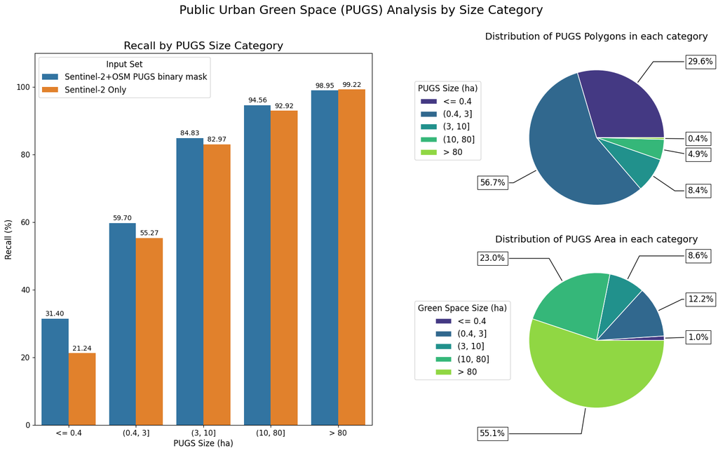

```python
plot_result_analysis(area_groups, df_melted, summary_df, group_counts, graph_output_path)
```